# JKSE Forecasting

# Data

```r
library(dplyr)
library(forecast)
```

```r
library(graphics)
library(TTR)
library(TSA)
library(readxl)
df <- read.csv("D:\\Mine\\Kuliah Journey\\Semester 5\\MPDW\\mpdw_066\\^JKSE_historis.csv")
df <- df[963:1199, ]
head(df)
```

```
##                          Date     Open     High      Low    Close    Volume
## 963 2025-08-29 00:00:00+07:00 7899.887 7913.860 7765.596 7830.493 481348100
## 964 2025-09-01 00:00:00+07:00 7620.099 7783.418 7547.564 7736.066 358661000
## 965 2025-09-02 00:00:00+07:00 7771.334 7842.299 7771.334 7801.585 347812700
## 966 2025-09-03 00:00:00+07:00 7843.632 7911.618 7840.751 7885.863 351685500
## 967 2025-09-04 00:00:00+07:00 7873.843 7899.796 7855.742 7867.348 362349800
## 968 2025-09-08 00:00:00+07:00 7929.063 7934.991 7766.849 7766.849 336787200
##     Dividends Stock.Splits
## 963         0            0
## 964         0            0
## 965         0            0
## 966         0            0
## 967         0            0
## 968         0            0
```

# Eksplorasi Data

```r
library(rio)
View(df)
str(df)
```

```
## 'data.frame':    237 obs. of  8 variables:
##  $ Date        : chr  "2025-08-29 00:00:00+07:00" "2025-09-01 00:00:00+07:00" "2025-09-02 00:00:00+07:00" "2025-09-03 00:00:00+07:00" ...
##  $ Open        : num  7900 7620 7771 7844 7874 ...
##  $ High        : num  7914 7783 7842 7912 7900 ...
##  $ Low         : num  7766 7548 7771 7841 7856 ...
##  $ Close       : num  7830 7736 7802 7886 7867 ...
##  $ Volume      : int  481348100 358661000 347812700 351685500 362349800 336787200 335416000 263174400 289797900 289619100 ...
##  $ Dividends   : num  0 0 0 0 0 0 0 0 0 0 ...
##  $ Stock.Splits: num  0 0 0 0 0 0 0 0 0 0 ...
```

```r
dim(df)
```

```
## [1] 237   8
```

```r
colSums(is.na(df))
```

```
##         Date         Open         High          Low        Close       Volume
##            0            0            0            0            0            0
##    Dividends Stock.Splits
##            0            0
```

```r
df.ts <- ts(df$Close)
summary(df.ts)
```

```
##    Min. 1st Qu.  Median    Mean 3rd Qu.    Max.
##    5342    6402    7830    7508    8310    9135
```

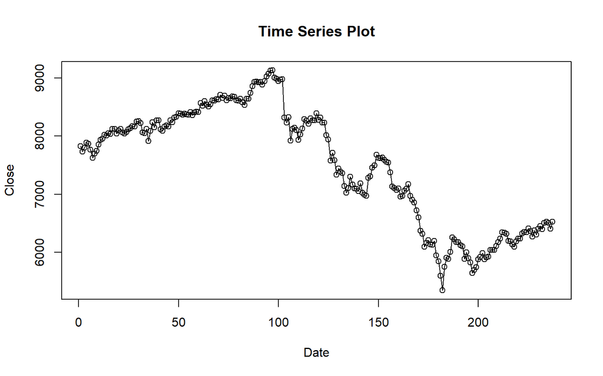

```r
ts.plot(df.ts, xlab="Date", ylab="Close",
        main = "Time Series Plot")
points(df.ts)
```

```r
#menyimpan plot
dev.copy(png, "plot_jkse_df.png")
```

```r
dev.off()
```

# MA

### Splitting

```r
n <- nrow(df)

n_train <- floor(0.8 * n)

# bagi data
training_ma <- df[1:n_train, ]
testing_ma  <- df[(n_train+1):n, ]

# ubah ke time series
train_ma.ts <- ts(training_ma$Close)
test_ma.ts  <- ts(testing_ma$Close)
```

### Eksplorasi

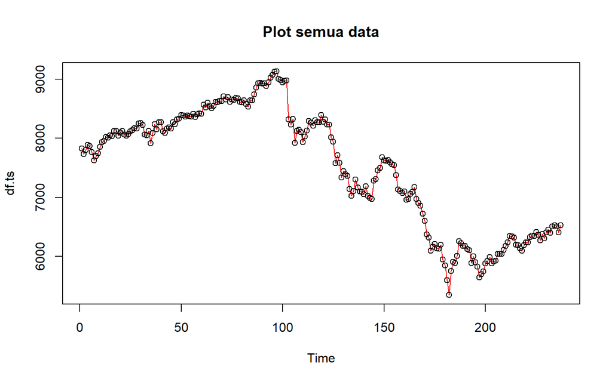

```r
#eksplorasi keseluruhan data
plot(df.ts, col="red",main="Plot semua data")
points(df.ts)
```

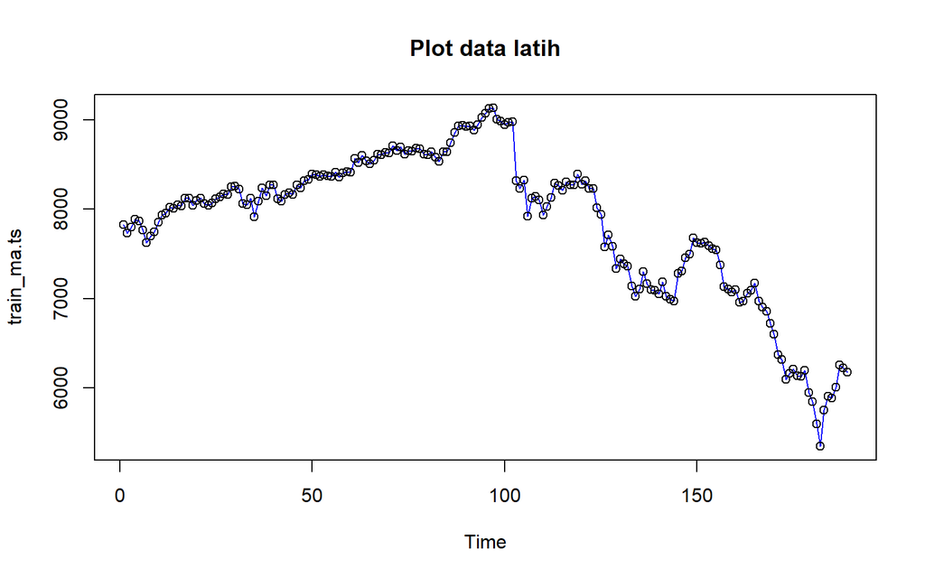

```r
#eksplorasi data latih
plot(train_ma.ts, col="blue",main="Plot data latih")
points(train_ma.ts)
```

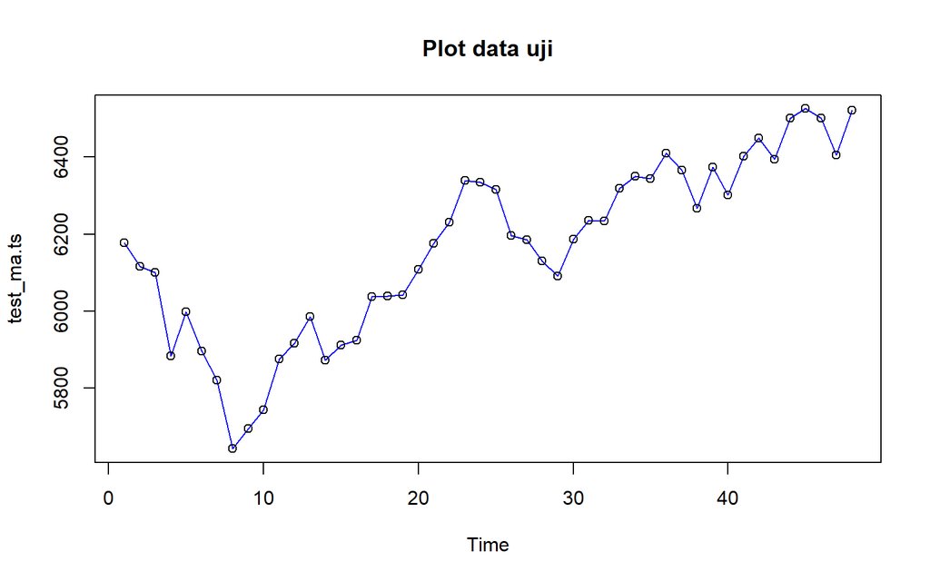

```r
#eksplorasi data uji
plot(test_ma.ts, col="blue",main="Plot data uji")
points(test_ma.ts)
```

```r
training_ma <- training_ma %>%
  mutate(Date = as.Date(Date))

testing_ma <- testing_ma %>%
  mutate(Date = as.Date(Date))

training_ma$Date <- as.Date(training_ma$Date)
testing_ma$Date <- as.Date(testing_ma$Date)
```

### Plot Split

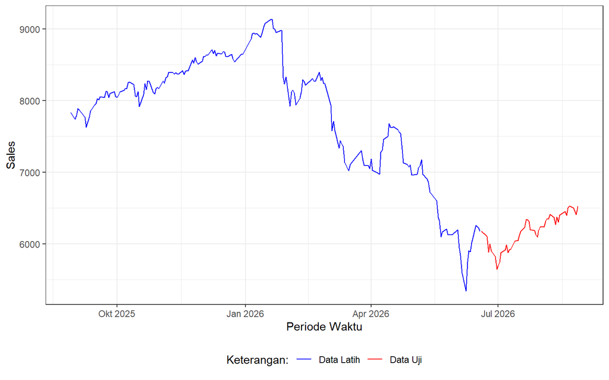

```r
library(ggplot2)
ggplot() +
  geom_line(data = training_ma, aes(x = Date, y = Close, col = "Data Latih")) +
  geom_line(data = testing_ma, aes(x = Date, y = Close, col = "Data Uji")) +
  labs(x = "Periode Waktu", y = "Sales", color = "Legend") +
   scale_colour_manual(name="Keterangan:", breaks = c("Data Latih", "Data Uji"),
                      values = c("blue", "red")) +
  theme_bw() + theme(legend.position = "bottom",
                     plot.caption = element_text(hjust=0.5, size=12))
```

## SMA

```r
df.sma<-SMA(train_ma.ts, n=5)
head(df.sma)
```

```
## Time Series:
## Start = 1
## End = 6
## Frequency = 1
## [1]       NA       NA       NA       NA 7824.271 7811.542
```

```r
df.ramal<-c(NA,df.sma)
head(df.ramal) #forecast 1 periode ke depan
```

```
## [1]       NA       NA       NA       NA       NA 7824.271
```

```r
length(df.ts)
```

```
## [1] 237
```

```r
length(df.sma)
```

```
## [1] 189
```

```r
length(df.ramal)
```

```
## [1] 190
```

```r
df.gab<-cbind(
  aktual=c(df.ts),
  pemulusan=c(df.sma,rep(NA,48)),
  ramalan=c(df.ramal,rep(df.ramal[length(df.ramal)],47)))

df.gab
```

```
##          aktual pemulusan  ramalan
##   [1,] 7830.493        NA       NA
##   [2,] 7736.066        NA       NA
##   [3,] 7801.585        NA       NA
##   [4,] 7885.863        NA       NA
##   [5,] 7867.348  7824.271       NA
##   [6,] 7766.849  7811.542 7824.271
##   [7,] 7628.605  7790.050 7811.542
##   [8,] 7699.007  7769.534 7790.050
##   [9,] 7747.905  7741.943 7769.534
##  [10,] 7854.060  7739.285 7741.943
##  [11,] 7937.118  7773.339 7739.285
##  [12,] 7957.696  7839.157 7773.339
##  [13,] 8025.179  7904.392 7839.157
##  [14,] 8008.433  7956.497 7904.392
```

[output cut: 223 more lines]

### Plot

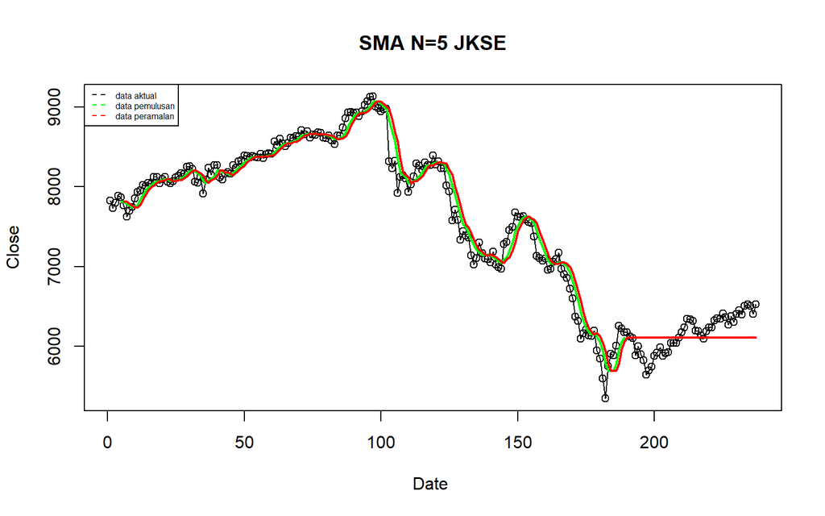

```r
ts.plot(df.ts, xlab="Date ", ylab="Close", main= "SMA N=5 JKSE")
points(df.ts)
lines(df.gab[,2],col="green",lwd=2)
lines(df.gab[,3],col="red",lwd=2)
legend("topleft",c("data aktual","data pemulusan","data peramalan"), lty=8, col=c("black","green","red"), cex=0.5)
```

### Akurasi Data Latih

```r
#Menghitung nilai keakuratan data latih
error_train.sma = train_ma.ts-df.ramal[1:length(train_ma.ts)]

SSE_train.sma = sum(error_train.sma[6:length(train_ma.ts)]^2)
MSE_train.sma = mean(error_train.sma[6:length(train_ma.ts)]^2)
MAPE_train.sma = mean(abs((error_train.sma[6:length(train_ma.ts)]/train_ma.ts[6:length(train_ma.ts)])*100))

akurasi_train.sma <- matrix(c(SSE_train.sma, MSE_train.sma, MAPE_train.sma))
row.names(akurasi_train.sma)<- c("SSE", "MSE", "MAPE")
colnames(akurasi_train.sma) <- c("Akurasi m = 5")
akurasi_train.sma
```

```
##      Akurasi m = 5
## SSE   6.759183e+06
## MSE   3.673469e+04
## MAPE  1.858338e+00
```

### Akurasi Data Uji

```r
#Menghitung nilai keakuratan data uji
error_test.sma = test_ma.ts-df.gab[190:237,3]

SSE_test.sma = sum(error_test.sma^2)
MSE_test.sma = mean(error_test.sma^2)
MAPE_test.sma = mean(abs((error_test.sma/test_ma.ts*100)))

akurasi_test.sma <- matrix(c(SSE_test.sma, MSE_test.sma, MAPE_test.sma))
row.names(akurasi_test.sma)<- c("SSE", "MSE", "MAPE")
colnames(akurasi_test.sma) <- c("Akurasi m = 5")
akurasi_test.sma
```

```
##      Akurasi m = 5
## SSE   2.658547e+06
## MSE   5.538640e+04
## MAPE  3.247497e+00
```

## DMA

```r
dma <- SMA(df.sma, n = 5)
At <- 2*df.sma - dma
Bt <- 2/(5-1)*(df.sma - dma)
df.dma<- At+Bt
df.ramal2<- c(NA, df.dma)

t = 1:48
f = c()

for (i in t) {
  f[i] = At[length(At)] + Bt[length(Bt)]*(i) }

df.gab2 <- cbind(aktual = c(df.ts),
                   pemulusan1 = c(df.sma,rep(NA,48)),
                   pemulusan2 = c(dma, rep(NA,48)),
                   At = c(At, rep(NA,48)),
                   Bt = c(Bt,rep(NA,48)),
                   ramalan = c(df.ramal2, f[-1]))
df.gab2
```

```
##          aktual pemulusan1 pemulusan2       At           Bt   ramalan
##   [1,] 7830.493         NA         NA       NA           NA        NA
##   [2,] 7736.066         NA         NA       NA           NA        NA
##   [3,] 7801.585         NA         NA       NA           NA        NA
##   [4,] 7885.863         NA         NA       NA           NA        NA
##   [5,] 7867.348   7824.271         NA       NA           NA        NA
##   [6,] 7766.849   7811.542         NA       NA           NA        NA
##   [7,] 7628.605   7790.050         NA       NA           NA        NA
##   [8,] 7699.007   7769.534         NA       NA           NA        NA
##   [9,] 7747.905   7741.943   7787.468 7696.417  -22.7626465        NA
##  [10,] 7854.060   7739.285   7770.471 7708.099  -15.5928711  7673.655
##  [11,] 7937.118   7773.339   7762.830 7783.848    5.2543555  7692.507
##  [12,] 7957.696   7839.157   7772.652 7905.663   33.2527246  7789.102
##  [13,] 8025.179   7904.392   7799.623 8009.160   52.3842383  7938.915
##  [14,] 8008.433   7956.497   7842.534 8070.461   56.9816211  8061.544
```

[output cut: 223 more lines]

### Plot

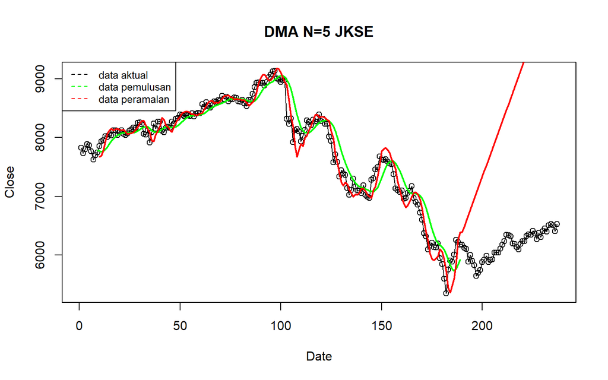

```r
ts.plot(df.ts, xlab="Date", ylab="Close", main= "DMA N=5 JKSE")
points(df.ts)
lines(df.gab2[,3],col="green",lwd=2)
lines(df.gab2[,6],col="red",lwd=2)
legend("topleft",c("data aktual","data pemulusan","data peramalan"), lty=8, col=c("black","green","red"), cex=0.8)
```

### Akurasi Data Latih

```r
#Menghitung nilai keakuratan data latih
error_train.dma = train_ma.ts-df.ramal2[1:length(train_ma.ts)]

SSE_train.dma = sum(error_train.dma[10:length(train_ma.ts)]^2)
MSE_train.dma = mean(error_train.dma[10:length(train_ma.ts)]^2)
MAPE_train.dma = mean(abs((error_train.dma[10:length(train_ma.ts)]/train_ma.ts[10:length(train_ma.ts)])*100))

akurasi_train.dma <- matrix(c(SSE_train.dma, MSE_train.dma, MAPE_train.dma))
row.names(akurasi_train.dma)<- c("SSE", "MSE", "MAPE")
colnames(akurasi_train.dma) <- c("Akurasi m = 5")
akurasi_train.dma
```

```
##      Akurasi m = 5
## SSE   5.130087e+06
## MSE   2.850048e+04
## MAPE  1.730432e+00
```

### Akurasi Data Uji

```r
#Menghitung nilai keakuratan data uji
error_test.dma = test_ma.ts-df.gab2[190:237,6]
SSE_test.dma = sum(error_test.dma^2)
MSE_test.dma = mean(error_test.dma^2)
MAPE_test.dma = mean(abs((error_test.dma/test_ma.ts*100)))

akurasi_test.dma <- matrix(c(SSE_test.dma, MSE_test.dma, MAPE_test.dma))
row.names(akurasi_test.dma)<- c("SSE", "MSE", "MAPE")
colnames(akurasi_test.dma) <- c("Akurasi m = 5")
akurasi_test.dma
```

```
##      Akurasi m = 5
## SSE   3.505964e+08
## MSE   7.304093e+06
## MAPE  3.937455e+01
```

# Exponential Smoothing

## SES

### Data Split

```r
n <- nrow(df)

n_train <- floor(0.8 * n)

# bagi data
training <- df[1:n_train, ]
testing  <- df[(n_train+1):n, ]

# ubah ke time series
train.ts <- ts(training$Close)
test.ts  <- ts(testing$Close)
```

## Single Exponential Smoothing

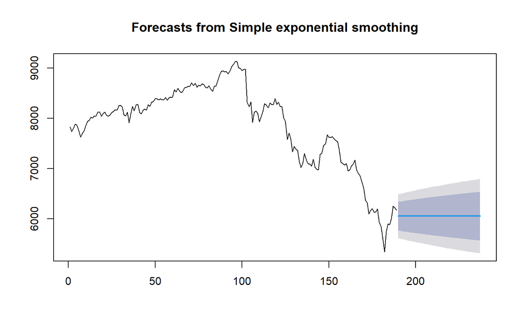

```r
ses.1 <- ses(train.ts, h = 48, alpha = 0.2)
plot(ses.1)
```

```r
ses.1
```

```
##     Point Forecast    Lo 80    Hi 80    Lo 95    Hi 95
## 190       6053.058 5767.931 6338.185 5616.994 6489.122
## 191       6053.058 5762.285 6343.831 5608.358 6497.758
## 192       6053.058 5756.746 6349.371 5599.887 6506.229
## 193       6053.058 5751.308 6354.808 5591.571 6514.545
## 194       6053.058 5745.967 6360.149 5583.403 6522.713
## 195       6053.058 5740.717 6365.399 5575.374 6530.742
## 196       6053.058 5735.554 6370.562 5567.478 6538.638
## 197       6053.058 5730.474 6375.642 5559.708 6546.408
## 198       6053.058 5725.472 6380.644 5552.059 6554.057
## 199       6053.058 5720.546 6385.570 5544.525 6561.591
## 200       6053.058 5715.691 6390.425 5537.100 6569.016
## 201       6053.058 5710.906 6395.210 5529.781 6576.335
## 202       6053.058 5706.186 6399.930 5522.564 6583.553
## 203       6053.058 5701.530 6404.586 5515.442 6590.674
```

[output cut: 34 more lines]

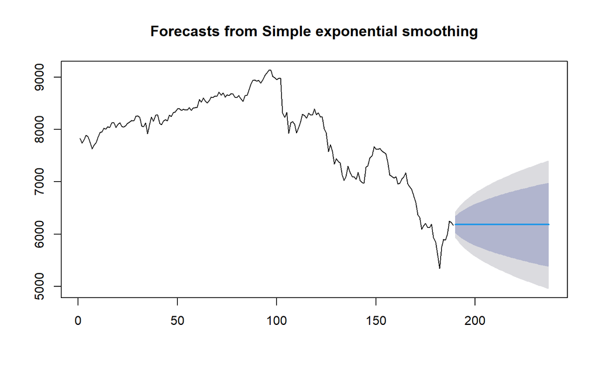

```r
ses.2<- ses(train.ts, h = 48, alpha = 0.7)
plot(ses.2)
```

```r
ses.2
```

```
##     Point Forecast    Lo 80    Hi 80    Lo 95    Hi 95
## 190       6182.138 6018.666 6345.610 5932.129 6432.146
## 191       6182.138 5982.595 6381.681 5876.964 6487.312
## 192       6182.138 5952.113 6412.163 5830.345 6533.931
## 193       6182.138 5925.222 6439.054 5789.219 6575.057
## 194       6182.138 5900.891 6463.385 5752.007 6612.269
## 195       6182.138 5878.503 6485.773 5717.768 6646.508
## 196       6182.138 5857.656 6506.620 5685.885 6678.390
## 197       6182.138 5838.070 6526.206 5655.931 6708.345
## 198       6182.138 5819.540 6544.736 5627.592 6736.683
## 199       6182.138 5801.912 6562.363 5600.633 6763.643
## 200       6182.138 5785.066 6579.209 5574.870 6789.406
## 201       6182.138 5768.907 6595.369 5550.155 6814.120
## 202       6182.138 5753.356 6610.920 5526.372 6837.904
## 203       6182.138 5738.349 6625.927 5503.421 6860.854
```

[output cut: 34 more lines]

### Plot

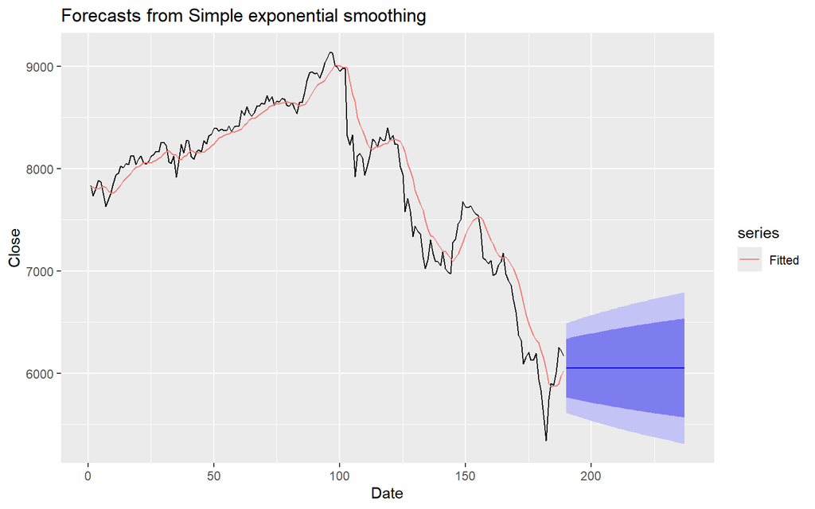

```r
autoplot(ses.1) +
  autolayer(fitted(ses.1), series="Fitted") +
  ylab("Close") + xlab("Date")
```

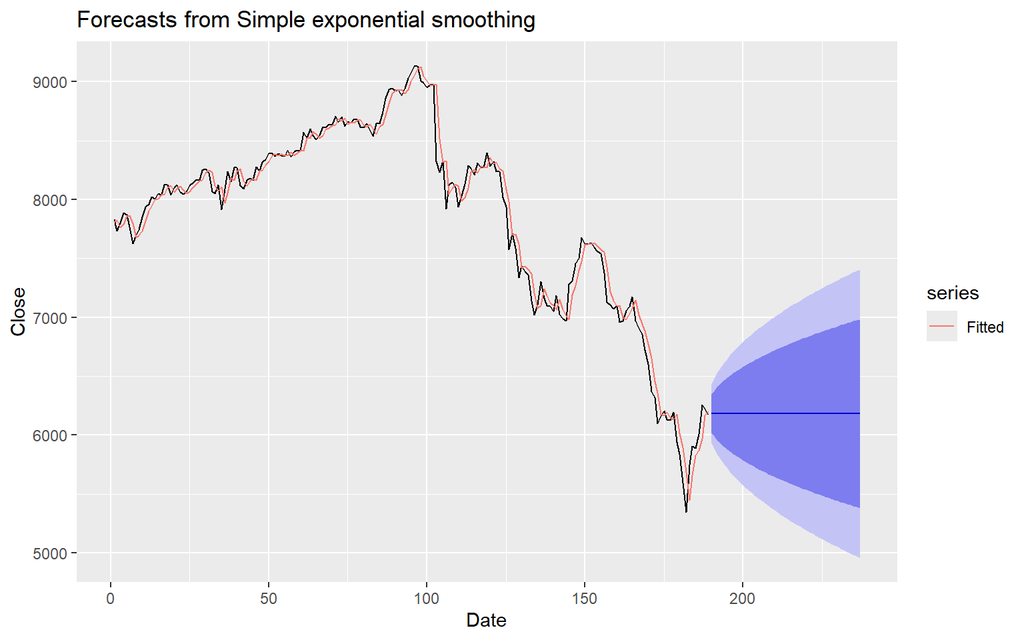

```r
autoplot(ses.2) +
  autolayer(fitted(ses.2), series="Fitted") +
  ylab("Close") + xlab("Date")
```

## Holt-Winter

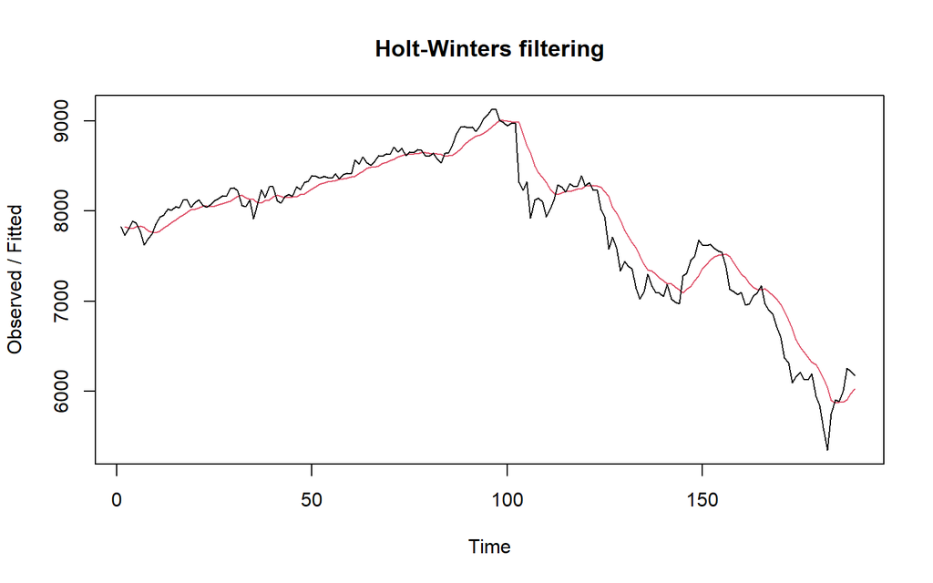

```r
ses1<- HoltWinters(train.ts, gamma = FALSE, beta = FALSE, alpha = 0.2)
plot(ses1)
```

```r
ramalan1<- forecast(ses1, h=48)
ramalan1
```

```
##     Point Forecast    Lo 80    Hi 80    Lo 95    Hi 95
## 190       6053.058 5774.470 6331.646 5626.995 6479.121
## 191       6053.058 5768.953 6337.163 5618.557 6487.559
## 192       6053.058 5763.541 6342.575 5610.280 6495.836
## 193       6053.058 5758.228 6347.888 5602.155 6503.961
## 194       6053.058 5753.010 6353.106 5594.174 6511.942
## 195       6053.058 5747.880 6358.236 5586.329 6519.787
## 196       6053.058 5742.836 6363.280 5578.614 6527.502
## 197       6053.058 5737.872 6368.244 5571.022 6535.094
## 198       6053.058 5732.985 6373.131 5563.549 6542.568
## 199       6053.058 5728.172 6377.945 5556.187 6549.929
## 200       6053.058 5723.428 6382.688 5548.933 6557.183
## 201       6053.058 5718.753 6387.363 5541.782 6564.334
## 202       6053.058 5714.141 6391.975 5534.730 6571.386
## 203       6053.058 5709.592 6396.524 5527.772 6578.344
```

[output cut: 34 more lines]

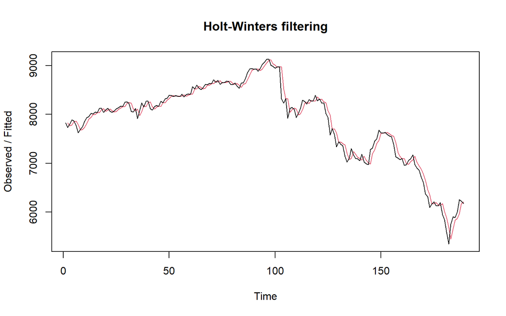

```r
ses2<- HoltWinters(train.ts, gamma = FALSE, beta = FALSE, alpha = 0.7)
plot(ses2)
```

```r
#ramalan
ramalan2<- forecast(ses2, h=48)
ramalan2
```

```
##     Point Forecast    Lo 80    Hi 80    Lo 95    Hi 95
## 190       6182.138 6019.448 6344.828 5933.325 6430.951
## 191       6182.138 5983.549 6380.726 5878.423 6485.853
## 192       6182.138 5953.213 6411.063 5832.027 6532.249
## 193       6182.138 5926.450 6437.825 5791.098 6573.178
## 194       6182.138 5902.235 6462.040 5754.064 6610.212
## 195       6182.138 5879.954 6484.321 5719.988 6644.288
## 196       6182.138 5859.207 6505.068 5688.258 6676.018
## 197       6182.138 5839.715 6524.561 5658.447 6705.829
## 198       6182.138 5821.274 6543.002 5630.244 6734.032
## 199       6182.138 5803.730 6560.545 5603.414 6760.862
## 200       6182.138 5786.965 6577.311 5577.773 6786.503
## 201       6182.138 5770.883 6593.393 5553.177 6811.099
## 202       6182.138 5755.406 6608.870 5529.507 6834.768
## 203       6182.138 5740.471 6623.805 5506.667 6857.609
```

[output cut: 34 more lines]

## Optimum

### SES

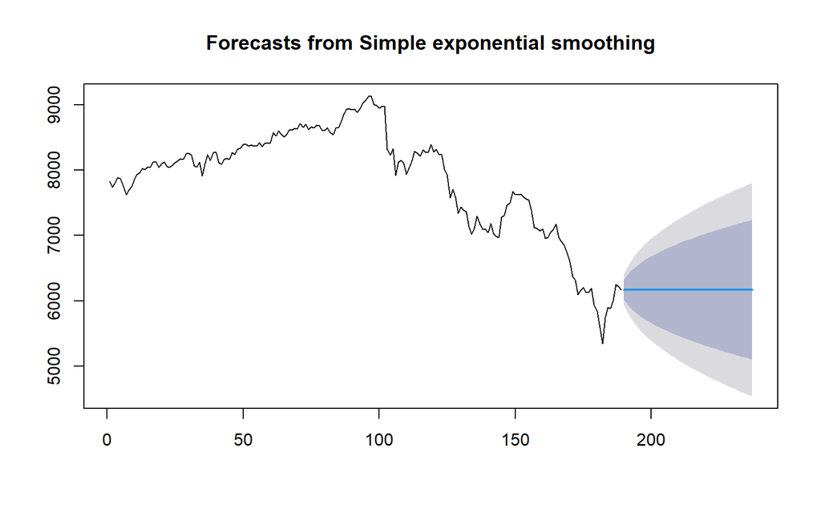

```r
ses.opt <- ses(train.ts, h = 48, alpha = NULL)
plot(ses.opt)
```

```r
ses.opt
```

```
##     Point Forecast    Lo 80    Hi 80    Lo 95    Hi 95
## 190       6172.345 6018.403 6326.287 5936.911 6407.778
## 191       6172.345 5954.649 6390.040 5839.408 6505.282
## 192       6172.345 5905.727 6438.962 5764.589 6580.101
## 193       6172.345 5864.484 6480.205 5701.513 6643.177
## 194       6172.345 5828.148 6516.541 5645.941 6698.748
## 195       6172.345 5795.297 6549.392 5595.701 6748.989
## 196       6172.345 5765.088 6579.601 5549.499 6795.190
## 197       6172.345 5736.970 6607.720 5506.496 6838.193
## 198       6172.345 5710.560 6634.129 5466.107 6878.583
## 199       6172.345 5685.582 6659.107 5427.905 6916.784
## 200       6172.345 5661.824 6682.865 5391.571 6953.119
## 201       6172.345 5639.124 6705.566 5356.854 6987.836
## 202       6172.345 5617.351 6727.338 5323.555 7021.134
## 203       6172.345 5596.401 6748.289 5291.515 7053.175
```

[output cut: 34 more lines]

### HW Parameter Optimum

```r
#Lamda Optimum Holt Winter
HWopt<- HoltWinters(train.ts, gamma = FALSE, beta = FALSE,alpha = NULL)
HWopt
```

```
## Holt-Winters exponential smoothing without trend and without seasonal component.
##
## Call:
## HoltWinters(x = train.ts, alpha = NULL, beta = FALSE, gamma = FALSE)
##
## Smoothing parameters:
##  alpha: 0.9999545
##  beta : FALSE
##  gamma: FALSE
##
## Coefficients:
##       [,1]
## a 6172.342
```

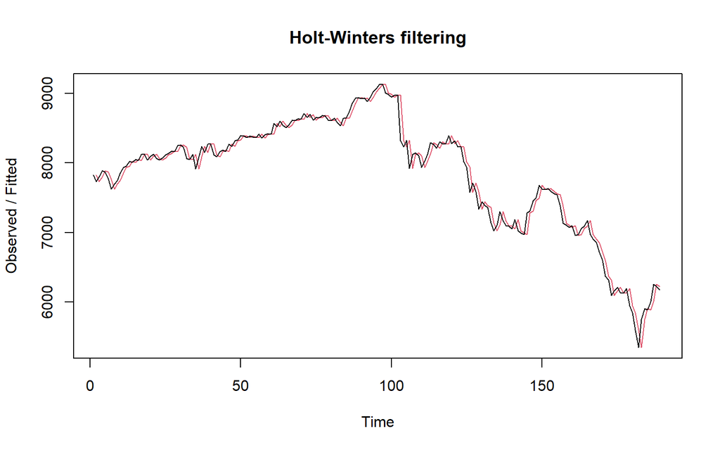

```r
plot(HWopt)
```

```r
ramalanopt<- forecast(HWopt, h=48)
ramalanopt
```

```
##     Point Forecast    Lo 80    Hi 80    Lo 95    Hi 95
## 190       6172.342 6018.818 6325.866 5937.548 6407.137
## 191       6172.342 5955.231 6389.453 5840.300 6504.384
## 192       6172.342 5906.439 6438.245 5765.678 6579.006
## 193       6172.342 5865.305 6479.379 5702.769 6641.915
## 194       6172.342 5829.065 6515.619 5647.345 6697.339
## 195       6172.342 5796.301 6548.383 5597.237 6747.447
## 196       6172.342 5766.172 6578.512 5551.158 6793.526
## 197       6172.342 5738.128 6606.556 5508.269 6836.415
## 198       6172.342 5711.789 6632.895 5467.987 6876.697
## 199       6172.342 5686.877 6657.807 5429.887 6914.797
## 200       6172.342 5663.182 6681.502 5393.649 6951.035
## 201       6172.342 5640.542 6704.142 5359.024 6985.660
## 202       6172.342 5618.827 6725.857 5325.814 7018.870
## 203       6172.342 5597.933 6746.751 5293.859 7050.825
```

[output cut: 34 more lines]

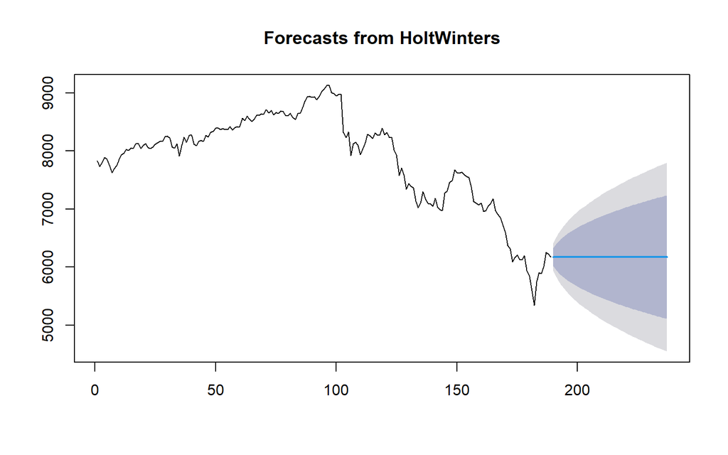

```r
plot(ramalanopt)
```

### Akurasi Data Latih

```r
#Keakuratan Metode
#Pada data training

# SES dengan alpha = 0.2
SSE1<-ses1$SSE
MSE1<-ses1$SSE/length(train.ts)
RMSE1<-sqrt(MSE1)

akurasi1 <- matrix(c(SSE1,MSE1,RMSE1))
row.names(akurasi1)<- c("SSE", "MSE", "RMSE")
colnames(akurasi1) <- c("Akurasi lamda=0.2")
akurasi1
```

```
##      Akurasi lamda=0.2
## SSE       9256889.4904
## MSE         48978.2513
## RMSE          221.3103
```

```r
SSE2<-ses2$SSE
MSE2<-ses2$SSE/length(train.ts)
RMSE2<-sqrt(MSE2)

akurasi2 <- matrix(c(SSE2,MSE2,RMSE2))
row.names(akurasi2)<- c("SSE", "MSE", "RMSE")
colnames(akurasi2) <- c("Akurasi lamda=0.7")
akurasi2
```

```
##      Akurasi lamda=0.7
## SSE       3043136.2658
## MSE         16101.2501
## RMSE          126.8907
```

### Akurasi Data

```r
accuracy(ramalan1, testing$Close)
```

```
##                     ME     RMSE      MAE        MPE     MAPE     MASE      ACF1
## Training set -47.27221 221.8981 162.2019 -0.7701958 2.206704 1.960827 0.8337978
## Test set     111.26353 254.2298 217.8620  1.6676432 3.503478 2.633691        NA
```

```r
accuracy(ramalan2, testing$Close)
```

```
##                     ME     RMSE      MAE        MPE     MAPE     MASE      ACF1
## Training set -12.52550 127.2277  87.9605 -0.1998660 1.189247 1.063337 0.3328447
## Test set     -17.81629 229.2829 190.4223 -0.4292676 3.122499 2.301978        NA
```

```r
accuracy(ramalanopt, testing$Close)
```

```
##                     ME     RMSE       MAE        MPE     MAPE     MASE
## Training set -8.820354 119.8014  82.72152 -0.1402090 1.110872 1.000004
## Test set     -8.020460 228.7303 191.16339 -0.2701336 3.129544 2.310937
##                    ACF1
## Training set 0.01584227
## Test set             NA
```

```r
accuracy(ses.opt, testing$Close)
```

```
##                     ME     RMSE       MAE        MPE     MAPE      MASE
## Training set -8.773796 119.4842  82.28462 -0.1394701 1.105006 0.9947226
## Test set     -8.023119 228.7304 191.16306 -0.2701768 3.129540 2.3109326
##                    ACF1
## Training set 0.01561359
## Test set             NA
```

```r
accuracy(ses.1, testing$Close)
```

```
##                     ME     RMSE      MAE       MPE     MAPE     MASE      ACF1
## Training set -46.69834 221.3053 161.3544 -0.761979 2.195127 1.950581 0.8333742
## Test set     111.26353 254.2298 217.8620  1.667643 3.503478 2.633691        NA
```

```r
accuracy(ses.2, testing$Close)
```

```
##                     ME     RMSE       MAE        MPE     MAPE     MASE
## Training set -12.30354 126.8810  87.58471 -0.1968150 1.184094 1.058794
## Test set     -17.81629 229.2829 190.42230 -0.4292676 3.122499 2.301978
##                   ACF1
## Training set 0.3320986
## Test set            NA
```

# Double Exponential Smoothing

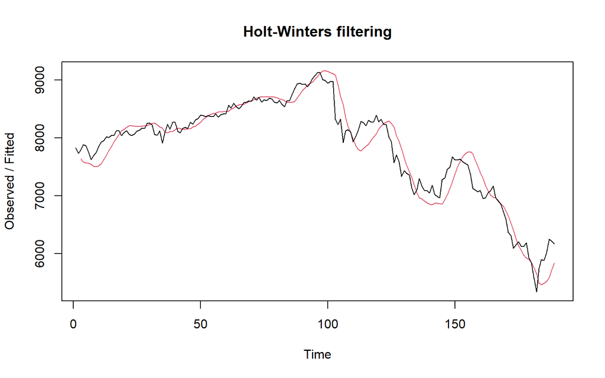

```r
des.1<- HoltWinters(train.ts, gamma = FALSE, beta = 0.2, alpha = 0.2)
plot(des.1)
```

```r
ramalandes1<- forecast(des.1, h=48)
ramalandes1
```

```
##     Point Forecast    Lo 80     Hi 80    Lo 95     Hi 95
## 190       5934.684 5631.868  6237.500 5471.567  6397.801
## 191       5965.415 5654.000  6276.830 5489.147  6441.683
## 192       5996.146 5673.395  6318.897 5502.540  6489.751
## 193       6026.876 5689.893  6363.860 5511.504  6542.249
## 194       6057.607 5703.429  6411.785 5515.939  6599.276
## 195       6088.338 5714.020  6462.656 5515.868  6660.807
## 196       6119.069 5721.745  6516.393 5511.414  6726.723
## 197       6149.799 5726.723  6572.875 5502.760  6796.838
## 198       6180.530 5729.101  6631.959 5490.129  6870.932
## 199       6211.261 5729.032  6693.490 5473.755  6948.766
## 200       6241.992 5726.670  6757.313 5453.876  7030.107
## 201       6272.722 5722.163  6823.281 5430.715  7114.729
## 202       6303.453 5715.647  6891.259 5404.481  7202.425
## 203       6334.184 5707.245  6961.122 5375.364  7293.004
```

[output cut: 34 more lines]

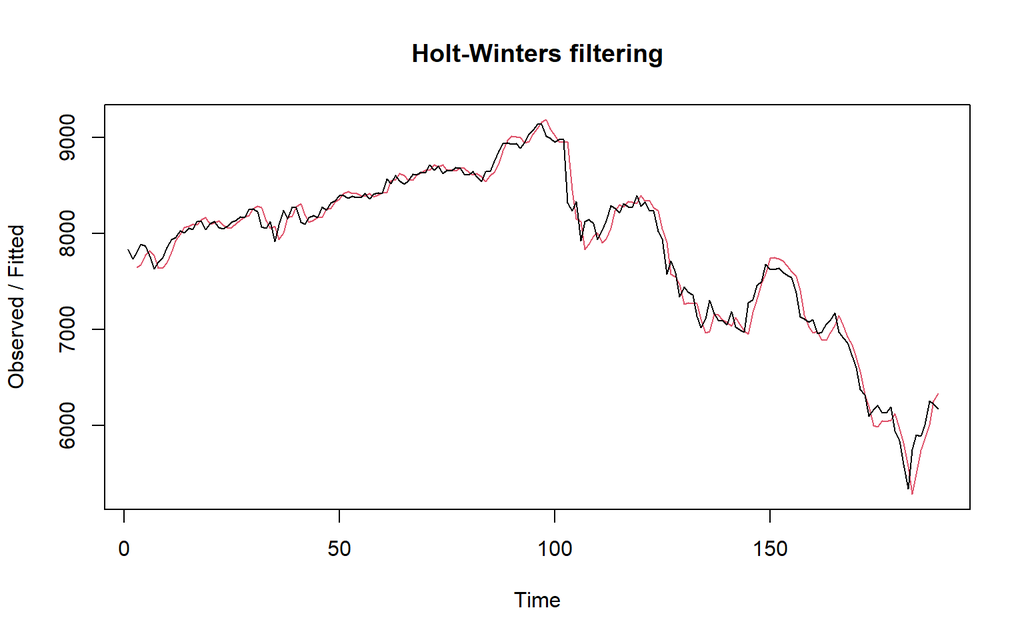

```r
des.2<- HoltWinters(train.ts, gamma = FALSE, beta = 0.3, alpha = 0.6)
plot(des.2)
```

```r
ramalandes2<- forecast(des.2, h=48)
ramalandes2
```

```
##     Point Forecast    Lo 80     Hi 80      Lo 95     Hi 95
## 190       6302.791 6132.594  6472.987 6042.49702  6563.084
## 191       6369.796 6153.948  6585.644 6039.68494  6699.908
## 192       6436.802 6166.087  6707.516 6022.77975  6850.824
## 193       6503.808 6170.743  6836.872 5994.42977  7013.185
## 194       6570.813 6169.062  6972.564 5956.38829  7185.238
## 195       6637.819 6161.815  7113.823 5909.83431  7365.804
## 196       6704.825 6149.545  7260.105 5855.59743  7554.052
## 197       6771.830 6132.651  7411.009 5794.29050  7749.370
## 198       6838.836 6111.444  7566.228 5726.38657  7951.286
## 199       6905.842 6086.172  7725.512 5652.26434  8159.419
## 200       6972.848 6057.037  7888.658 5572.23618  8373.459
## 201       7039.853 6024.213  8055.493 5486.56596  8593.141
## 202       7106.859 5987.849  8225.869 5395.48099  8818.237
## 203       7173.865 5948.074  8399.655 5299.18017  9048.549
```

[output cut: 34 more lines]

### Plot

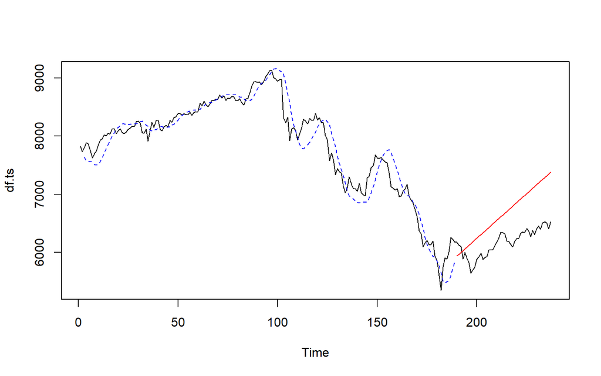

```r
plot(df.ts)
lines(des.1$fitted[,1], lty=2, col="blue")
lines(ramalandes1$mean, col="red")
```

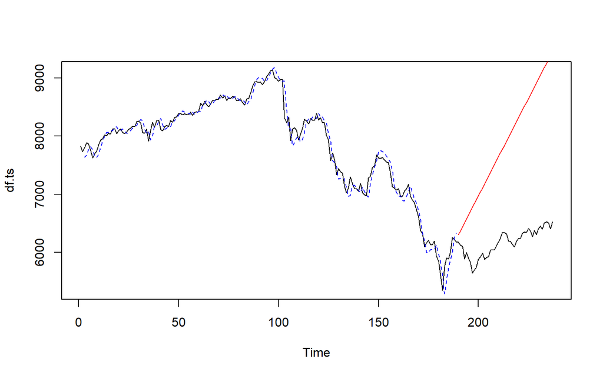

```r
plot(df.ts)
lines(des.2$fitted[,1], lty=2, col="blue")
lines(ramalandes2$mean, col="red")
```

### Optimum Parameter

```r
#Lamda dan gamma optimum
des.opt<- HoltWinters(train.ts, gamma = FALSE)
des.opt
```

```
## Holt-Winters exponential smoothing with trend and without seasonal component.
##
## Call:
## HoltWinters(x = train.ts, gamma = FALSE)
##
## Smoothing parameters:
##  alpha: 1
##  beta : 0.06894169
##  gamma: FALSE
##
## Coefficients:
##          [,1]
## a 6172.339844
## b   -9.614007
```

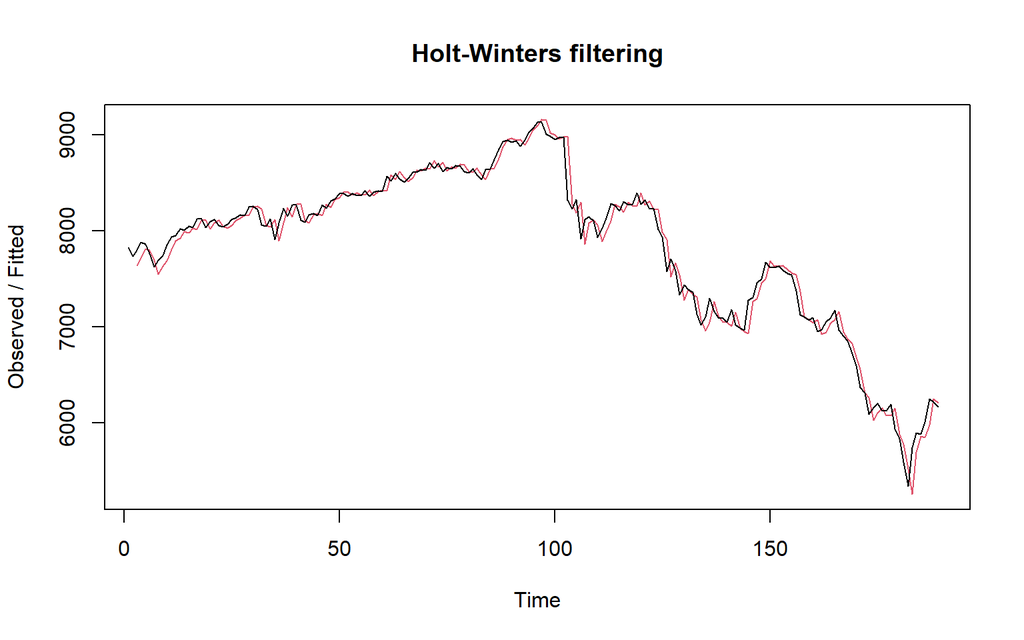

```r
plot(des.opt)
```

```r
ramalandesopt<- forecast(des.opt, h=48)
ramalandesopt
```

```
##     Point Forecast    Lo 80    Hi 80    Lo 95     Hi 95
## 190       6162.726 6004.705 6320.747 5921.053  6404.398
## 191       6153.112 5921.804 6384.419 5799.358  6506.866
## 192       6143.498 5850.522 6436.473 5695.430  6591.565
## 193       6133.884 5784.309 6483.459 5599.255  6668.513
## 194       6124.270 5720.730 6527.810 5507.109  6741.431
## 195       6114.656 5658.588 6570.723 5417.161  6812.151
## 196       6105.042 5597.204 6612.880 5328.371  6881.713
## 197       6095.428 5536.154 6654.701 5240.093  6950.763
## 198       6085.814 5475.160 6696.467 5151.900  7019.728
## 199       6076.200 5414.030 6738.370 5063.498  7088.902
## 200       6066.586 5352.626 6780.546 4974.678  7158.493
## 201       6056.972 5290.849 6823.094 4885.288  7228.655
## 202       6047.358 5228.626 6866.090 4795.215  7299.500
## 203       6037.744 5165.901 6909.587 4704.375  7371.112
```

[output cut: 34 more lines]

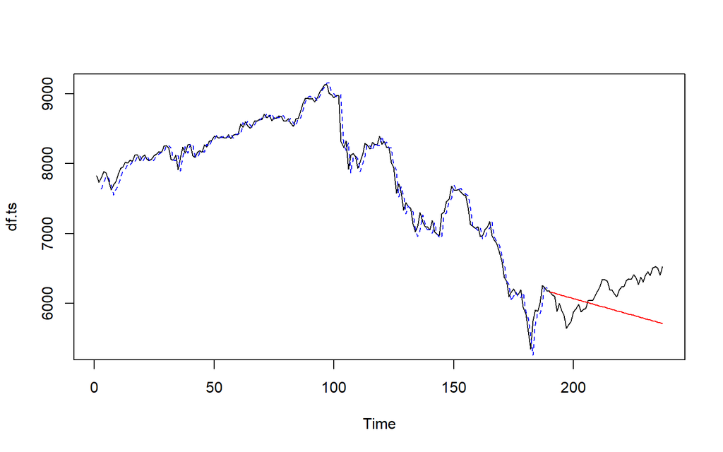

```r
plot(df.ts)
lines(des.opt$fitted[,1], lty=2, col="blue")
lines(ramalandesopt$mean, col="red")
```

### Akurasi Data Latih

```r
ssedes.train1<-des.1$SSE
msedes.train1<-ssedes.train1/length(train.ts)
sisaandes1<-ramalandes1$residuals
head(sisaandes1)
```

```
## Time Series:
## Start = 1
## End = 6
## Frequency = 1
## [1]       NA       NA 159.9463 300.2643 297.7156 201.7836
```

```r
mapedes.train1 <- sum(abs(sisaandes1[3:length(train.ts)]/train.ts[3:length(train.ts)])
                      *100)/length(train.ts)

akurasides.1 <- matrix(c(ssedes.train1,msedes.train1,mapedes.train1))
row.names(akurasides.1)<- c("SSE", "MSE", "MAPE")
colnames(akurasides.1) <- c("Akurasi lamda=0.2 dan gamma=0.2")
akurasides.1
```

```
##      Akurasi lamda=0.2 dan gamma=0.2
## SSE                     1.043715e+07
## MSE                     5.522303e+04
## MAPE                    2.304886e+00
```

```r
ssedes.train2<-des.2$SSE
msedes.train2<-ssedes.train2/length(train.ts)
sisaandes2<-ramalandes2$residuals
head(sisaandes2)
```

```
## Time Series:
## Start = 1
## End = 6
## Frequency = 1
## [1]        NA        NA 159.94629 213.89326  94.17878 -52.64356
```

```r
mapedes.train2 <- sum(abs(sisaandes2[3:length(train.ts)]/train.ts[3:length(train.ts)])
                      *100)/length(train.ts)

akurasides.2 <- matrix(c(ssedes.train2,msedes.train2,mapedes.train2))
row.names(akurasides.2)<- c("SSE", "MSE", "MAPE")
colnames(akurasides.2) <- c("Akurasi lamda=0.6 dan gamma=0.3")
akurasides.2
```

```
##      Akurasi lamda=0.6 dan gamma=0.3
## SSE                     3.284827e+06
## MSE                     1.738004e+04
## MAPE                    1.302428e+00
```

### Akurasi Data Uji

```r
selisihdes1<-ramalandes1$mean-testing$Close
selisihdes1
```

```
## Time Series:
## Start = 190
## End = 237
## Frequency = 1
##  [1] -242.45490 -151.27495 -105.18729  142.99558   58.56908  192.20410
##  [7]  298.27858  506.60549  485.41386  466.70464  366.21173  356.65242
## [13]  316.95590  460.81163  452.47253  471.28528  388.53408  417.58560
## [19]  445.86516  410.35907  373.76362  348.24972  270.74021  307.01488
## [25]  356.91064  506.52223  547.89993  633.82597  703.75835  639.51252
## [31]  620.48006  652.83969  598.45469  597.65905  635.81800  600.60585
## [37]  675.61636  803.84123  728.60272  831.41743  762.02511  744.81394
## [43]  831.24974  754.52051  761.14625  815.89993  942.61259  857.27837
```

```r
SSEtestingdes1<-sum(selisihdes1^2)
MSEtestingdes1<-SSEtestingdes1/length(testing$Close)
MAPEtestingdes1<-sum(abs(selisihdes1/testing$Close)*100)/length(testing$Close)

selisihdes2<-ramalandes2$mean-testing$Close
selisihdes2
```

```
## Time Series:
## Start = 190
## End = 237
## Frequency = 1
##  [1]  125.6514  253.1063  335.4689  619.9268  571.7752  741.6852  884.0347
##  [8] 1128.6366 1143.7199 1161.2857 1097.0677 1123.7834 1120.3619 1300.4926
## [15] 1328.4284 1383.5162 1337.0399 1402.3664 1466.9210 1467.6898 1467.3694
## [22] 1478.1304 1436.8959 1509.4456 1595.6163 1781.5029 1859.1555 1981.3565
## [29] 2087.5639 2059.5930 2076.8355 2145.4702 2127.3601 2162.8395 2237.2734
## [36] 2238.3362 2349.6217 2514.1215 2475.1580 2614.2477 2581.1303 2600.1941
## [43] 2722.9049 2682.4507 2725.3514 2816.3800 2979.3677 2930.3084
```

```r
SSEtestingdes2<-sum(selisihdes2^2)
MSEtestingdes2<-SSEtestingdes2/length(testing$Close)
MAPEtestingdes2<-sum(abs(selisihdes2/testing$Close)*100)/length(testing$Close)

selisihdesopt<-ramalandesopt$mean-testing$Close
selisihdesopt
```

```
## Time Series:
## Start = 190
## End = 237
## Frequency = 1
##  [1]  -14.41332   36.42189   42.16482  250.00296  125.23172  218.52202
##  [7]  284.25176  452.23394  390.69757  331.64363  190.80599  140.90194
## [13]   60.86069  164.37168  115.68785   94.15588  -28.94006  -40.23327
## [19]  -52.29845 -128.14927 -205.08945 -270.94809 -388.80233 -392.87239
## [25] -383.32136 -274.05450 -273.02154 -227.44023 -197.85258 -302.44315
## [31] -361.82034 -369.80544 -464.53517 -505.67554 -507.86132 -583.41820
## [37] -548.75242 -460.87229 -576.45553 -513.98556 -623.72261 -681.27851
## [43] -635.18744 -752.26141 -785.98039 -771.57145 -685.20352 -810.88247
```

```r
SSEtestingdesopt<-sum(selisihdesopt^2)
MSEtestingdesopt<-SSEtestingdesopt/length(testing$Close)
MAPEtestingdesopt<-sum(abs(selisihdesopt/testing$Close)*100)/length(testing$Close)

akurasitestingdes <-
  matrix(c(SSEtestingdes1,MSEtestingdes1,MAPEtestingdes1,SSEtestingdes2,MSEtestingdes2,
           MAPEtestingdes2,SSEtestingdesopt,MSEtestingdesopt,MAPEtestingdesopt),
         nrow=3,ncol=3)
row.names(akurasitestingdes)<- c("SSE", "MSE", "MAPE")
colnames(akurasitestingdes) <- c("des ske1","des ske2","des opt")
akurasitestingdes
```

```
##          des ske1     des ske2      des opt
## SSE  1.494522e+07 1.674942e+08 8.318097e+06
## MSE  3.113588e+05 3.489463e+06 1.732937e+05
## MAPE 8.261492e+00 2.749391e+01 5.565190e+00
```

# Seasonal Smoothing

```r
training <- training[,5]
testing <- testing[,5]
training.ts<-ts(training, frequency = 5)
testing.ts<-ts(testing, frequency = 5)
```

## Winter Aditif

### Pemulusan

```r
winter1 <- HoltWinters(training.ts,alpha=0.2,beta=0.1,gamma=0.1,seasonal = "additive")
winter1$fitted
```

```
## Time Series:
## Start = c(2, 1)
## End = c(38, 4)
## Frequency = 5
##          xhat    level       trend        season
##  2.0 7822.661 7844.862 -18.6926590   -3.50795898
##  2.2 7681.037 7815.007 -19.8089020 -114.16049805
##  2.4 7731.549 7784.711 -20.8575504  -32.30488281
##  2.6 7809.335 7757.345 -21.5083933   73.49790039
##  2.8 7777.289 7723.551 -22.7369964   76.47543945
##  3.0 7686.994 7716.168 -21.2015843   -7.97293090
##  3.2 7610.437 7744.991 -16.1990934 -118.35509154
##  3.4 7754.082 7798.244  -9.2539229  -34.90825436
##  3.6 7907.961 7843.210  -3.8319767   68.58348790
##  3.8 7940.267 7859.472  -1.8225370   82.61708792
##  4.0 7892.251 7879.820   0.3944946   12.03703269
##  4.2 7822.548 7909.772   3.3502491  -90.57440941
##  4.4 7969.836 7973.653   9.4033188  -13.22046993
##  4.6 8103.560 8014.401  12.5377680   76.62124670
##  4.8 8117.125 8014.359  11.2798764   91.48521461
##  5.0 8056.865 8022.081  10.9240456   23.86005076
##  5.2 7992.171 8046.281  12.2516455  -66.36213077
##  5.4 8085.258 8072.311  13.6294740   -0.68267298
##  5.6 8162.044 8077.653  12.8007535   71.58968017
##  5.8 8173.305 8072.261  10.9815005   90.06189134
##  6.0 8111.294 8072.242   9.8814184   29.17045036
##  6.2 8037.446 8087.844  10.4534185  -60.85081664
##  6.4 8133.756 8124.664  13.0901098   -3.99755498
##  6.6 8222.257 8144.208  13.7355564   64.31266823
##  6.8 8263.651 8163.680  14.3091914   85.66156298
##  7.0 8222.483 8176.831  14.1933557   31.45845040
##  7.2 8155.952 8191.968  14.2877377  -50.30405122
##  7.4 8199.453 8188.370  12.4991351   -1.41576861
##  7.6 8247.354 8171.214   9.5335613   66.60720839
##  7.8 8248.507 8156.228   7.0816121   85.19822009
##  8.0 8128.999 8096.739   0.4245788   31.83597852
##  8.2 8031.325 8089.159  -0.3758493  -57.45846169
##  8.4 8120.616 8130.135   3.7593332  -13.27806384
##  8.6 8201.479 8140.282   4.3980693   56.79941164
##  8.8 8223.680 8159.254   5.8555141   58.57008684
```

[output cut: 134 more lines]

```
## 35.8 6290.935 6353.316 -61.6057321   -0.77462635
## 36.0 6177.722 6274.793 -63.2974540  -33.77337628
## 36.2 6099.788 6201.989 -64.2480910  -37.95227339
## 36.4 6022.822 6143.259 -63.6962425  -56.74105743
## 36.6 6011.429 6114.084 -60.2441452  -42.41095895
## 36.8 5970.574 6039.767 -61.6514032   -7.54151377
## 37.0 5850.115 5951.958 -64.2671856  -37.57592427
## 37.2 5731.502 5836.621 -69.3741801  -35.74487930
## 37.4 5569.280 5689.374 -77.1614716  -42.93266816
## 37.6 5526.032 5647.686 -73.6141047  -48.03999099
## 37.8 5565.249 5649.341 -66.0872221  -18.00464370
## 38.0 5529.735 5647.410 -59.6715535  -58.00390209
## 38.2 5566.316 5683.323 -50.1131317  -66.89404512
## 38.4 5705.856 5770.940 -36.3401276  -28.74320061
## 38.6 5793.601 5837.576 -26.0424503  -17.93246056
```

```r
xhat1 <- winter1$fitted[,2]

winter1.opt<- HoltWinters(training.ts, alpha= NULL,  beta = NULL, gamma = NULL, seasonal = "additive")
winter1.opt
```

```
## Holt-Winters exponential smoothing with trend and additive seasonal component.
##
## Call:
## HoltWinters(x = training.ts, alpha = NULL, beta = NULL, gamma = NULL,     seasonal = "additive")
##
## Smoothing parameters:
##  alpha: 0.8761636
##  beta : 0.000531006
##  gamma: 1
##
## Coefficients:
##           [,1]
## a  6124.614269
## b   -17.863313
## s1   47.440378
## s2    6.817663
## s3   35.733870
## s4   83.031882
## s5   47.725575
```

```r
xhat1.opt <- winter1.opt$fitted[,2]
```

### Peramalan

```r
forecast1 <- predict(winter1, n.ahead = 48)
forecast1.opt <- predict(winter1.opt, n.ahead = 48)
```

### Plot

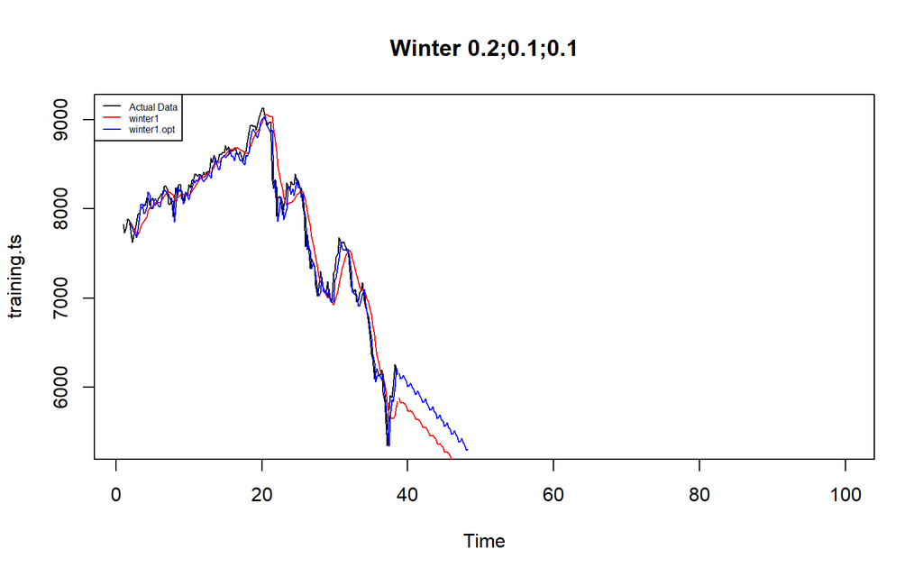

```r
#Plot time series
plot(training.ts,main="Winter 0.2;0.1;0.1",type="l",col="black",
     xlim=c(1,100),pch=12)
lines(xhat1,type="l",col="red")
lines(xhat1.opt,type="l",col="blue")
lines(forecast1,type="l",col="red")
lines(forecast1.opt,type="l",col="blue")
legend("topleft",c("Actual Data",expression(paste(winter1)),
                   expression(paste(winter1.opt))),cex=0.5,
       col=c("black","red","blue"),lty=1)
```

### Akurasi Data Latih

```r
#Akurasi data training
SSE1<-winter1$SSE
MSE1<-winter1$SSE/length(training.ts)
RMSE1<-sqrt(MSE1)
akurasi1 <- matrix(c(SSE1,MSE1,RMSE1))
row.names(akurasi1)<- c("SSE", "MSE", "RMSE")
colnames(akurasi1) <- c("Akurasi")
akurasi1
```

```
##           Akurasi
## SSE  9142807.8649
## MSE    48374.6448
## RMSE     219.9424
```

```r
SSE1.opt<-winter1.opt$SSE
MSE1.opt<-winter1.opt$SSE/length(training.ts)
RMSE1.opt<-sqrt(MSE1.opt)
akurasi1.opt <- matrix(c(SSE1.opt,MSE1.opt,RMSE1.opt))
row.names(akurasi1.opt)<- c("SSE1.opt", "MSE1.opt", "RMSE1.opt")
colnames(akurasi1.opt) <- c("Akurasi")
akurasi1.opt
```

```
##               Akurasi
## SSE1.opt  3098368.241
## MSE1.opt    16393.483
## RMSE1.opt     128.037
```

```r
akurasi1.train = data.frame(Model_Winter = c("Winter 1","Winter1 optimal"),
                            Nilai_SSE=c(SSE1,SSE1.opt),
                            Nilai_MSE=c(MSE1,MSE1.opt),Nilai_RMSE=c(RMSE1,RMSE1.opt))
akurasi1.train
```

```
##      Model_Winter Nilai_SSE Nilai_MSE Nilai_RMSE
## 1        Winter 1   9142808  48374.64   219.9424
## 2 Winter1 optimal   3098368  16393.48   128.0370
```

### Akurasi Data Uji

```r
forecast1<-data.frame(forecast1)
testing.ts<-data.frame(testing.ts)
selisih1<-forecast1-testing.ts
SSEtesting1<-sum(selisih1^2)
MSEtesting1<-SSEtesting1/length(testing.ts)

forecast1.opt<-data.frame(forecast1.opt)
selisih1.opt<-forecast1.opt-testing.ts
SSEtesting1.opt<-sum(selisih1.opt^2)
MSEtesting1.opt<-SSEtesting1.opt/length(testing.ts)
```

```r
akurasi_testing <- data.frame(
  Model = c("Model1", "Model Optimum"),
  SSE   = c(SSEtesting1, SSEtesting1.opt),
  MSE   = c(MSEtesting1, MSEtesting1.opt)
)

akurasi_testing
```

```
##           Model      SSE      MSE
## 1        Model1 35998752 35998752
## 2 Model Optimum 19162979 19162979
```

## Winter Mulplikatif

### Pemulusan

```r
winter2 <- HoltWinters(training.ts,alpha=0.2,beta=0.1,gamma=0.3,seasonal = "multiplicative")
winter2$fitted
```

```
## Time Series:
## Start = c(2, 1)
## End = c(38, 4)
## Frequency = 5
##          xhat    level       trend    season
##  2.0 7822.839 7844.862 -18.6926590 0.9995744
##  2.2 7680.423 7814.967 -19.8129281 0.9852817
##  2.4 7731.694 7784.635 -20.8647610 0.9958684
##  2.6 7808.659 7757.206 -21.5212157 1.0094335
##  2.8 7776.714 7723.647 -22.7249469 1.0098419
##  3.0 7678.542 7716.241 -21.1931077 0.9978550
##  3.2 7604.729 7746.874 -16.0104631 0.9836842
##  3.4 7753.712 7802.628  -8.8340307 0.9948571
##  3.6 7904.187 7848.368  -3.3766108 1.0075456
##  3.8 7960.697 7865.685  -1.3073035 1.0122476
##  4.0 7928.960 7882.243   0.4792336 1.0058657
##  4.2 7864.330 7904.808   2.6878590 0.9945411
##  4.4 7993.057 7959.957   7.9339249 1.0031585
##  4.6 8090.968 7994.507  10.5955346 1.0107264
##  4.8 8124.826 7995.148   9.6001447 1.0150008
##  5.0 8082.811 7999.725   9.0978211 1.0092382
##  5.2 8046.052 8016.836   9.8991084 1.0024066
##  5.4 8097.545 8029.730  10.1985827 1.0071663
##  5.6 8112.477 8029.260   9.1317669 1.0092164
##  5.8 8152.936 8030.188   8.3114066 1.0142360
##  6.0 8123.299 8031.670   7.6284332 1.0104487
##  6.2 8073.526 8042.583   7.9569010 1.0028552
##  6.4 8124.429 8069.637   9.8665389 1.0055605
##  6.6 8163.090 8087.777  10.6939379 1.0079792
##  6.8 8235.641 8115.902  12.4369950 1.0132010
##  7.0 8234.745 8132.724  12.8755764 1.0109439
##  7.2 8203.353 8144.108  12.7263533 1.0057031
##  7.4 8194.936 8129.623  10.0052499 1.0067949
##  7.6 8204.086 8111.070   7.1494237 1.0105770
##  7.8 8220.451 8102.520   5.5794490 1.0138567
##  8.0 8133.823 8047.973  -0.4331321 1.0107217
##  8.2 8050.717 8038.666  -1.3205222 1.0016636
##  8.4 8097.703 8074.757   2.4206013 1.0025411
##  8.6 8158.207 8088.120   3.5148301 1.0082272
##  8.8 8159.206 8114.674   5.8187749 1.0047673
```

[output cut: 134 more lines]

```
## 35.8 6283.375 6353.729 -59.2308953 0.9982329
## 36.0 6123.753 6279.066 -60.7741437 0.9847967
## 36.2 6064.074 6219.599 -60.6434123 0.9845946
## 36.4 5996.928 6171.815 -59.3574659 0.9810993
## 36.6 6019.655 6152.922 -55.3110029 0.9872153
## 36.8 5996.403 6081.690 -56.9031356 0.9952888
## 37.0 5844.533 5993.315 -60.0503113 0.9850451
## 37.2 5742.132 5882.552 -65.1215059 0.9870564
## 37.4 5599.967 5736.383 -73.2263123 0.9888419
## 37.6 5533.244 5692.824 -70.2595849 0.9841140
## 37.8 5572.938 5697.582 -62.7577720 0.9890171
## 38.0 5499.851 5698.139 -56.4263518 0.9748549
## 38.2 5530.720 5745.893 -46.0082944 0.9703213
## 38.4 5789.144 5849.164 -31.0803254 0.9950258
## 38.6 5880.447 5904.835 -22.4052421 0.9996630
```

```r
xhat2 <- winter2$fitted[,2]

winter2.opt<- HoltWinters(training.ts, alpha= NULL,  beta = NULL, gamma = NULL, seasonal = "multiplicative")
winter2.opt$fitted
```

```
## Time Series:
## Start = c(2, 1)
## End = c(38, 4)
## Frequency = 5
##          xhat    level     trend    season
##  2.0 7822.839 7844.862 -18.69266 0.9995744
##  2.2 7644.305 7777.190 -18.69266 0.9852817
##  2.4 7693.950 7744.563 -18.69266 0.9958684
##  2.6 7784.365 7730.310 -18.69266 1.0094335
##  2.8 7736.743 7680.034 -18.69266 1.0098419
##  3.0 7733.937 7762.926 -18.69266 0.9986704
##  3.2 7785.107 7922.137 -18.69266 0.9850272
##  3.4 8005.412 8056.654 -18.69266 0.9959506
##  3.6 8107.646 8055.316 -18.69266 1.0088373
##  3.8 8025.055 7950.629 -18.69266 1.0117396
##  4.0 7950.777 7954.463 -18.69266 1.0018910
##  4.2 7896.782 8013.676 -18.69266 0.9877172
##  4.4 8147.911 8197.202 -18.69266 0.9962587
##  4.6 8200.263 8159.768 -18.69266 1.0072703
##  4.8 8080.845 8002.525 -18.69266 1.0121511
##  5.0 8007.368 7999.805 -18.69266 1.0032898
##  5.2 7992.587 8082.106 -18.69266 0.9912164
##  5.4 8072.140 8123.820 -18.69266 0.9959301
##  5.6 8099.992 8080.264 -18.69266 1.0047659
##  5.8 8117.469 8036.410 -18.69266 1.0124413
##  6.0 8040.464 8018.437 -18.69266 1.0050902
##  6.2 8005.232 8086.248 -18.69266 0.9922748
##  6.4 8156.475 8212.120 -18.69266 0.9954900
##  6.6 8218.430 8201.819 -18.69266 1.0043142
##  6.8 8294.773 8211.431 -18.69266 1.0124543
##  7.0 8196.181 8160.857 -18.69266 1.0066343
##  7.2 8107.900 8169.111 -18.69266 0.9947834
##  7.4 8060.027 8114.046 -18.69266 0.9956363
##  7.6 8107.708 8087.578 -18.69266 1.0048113
##  7.8 8160.893 8083.722 -18.69266 1.0118863
##  8.0 7890.125 7853.107 -18.69266 1.0071111
##  8.2 7941.587 8007.068 -18.69266 0.9941430
##  8.4 8193.428 8249.167 -18.69266 0.9954988
##  8.6 8217.381 8194.571 -18.69266 1.0050762
##  8.8 8272.117 8225.444 -18.69266 1.0079649
```

[output cut: 134 more lines]

```
## 35.8 6153.815 6128.529 -18.69266 1.0071980
## 36.0 6132.134 6155.445 -18.69266 0.9992474
## 36.2 6142.787 6135.051 -18.69266 1.0043210
## 36.4 6101.367 6102.945 -18.69266 1.0028131
## 36.6 6181.196 6166.269 -18.69266 1.0054688
## 36.8 5969.007 5938.742 -18.69266 1.0082697
## 37.0 5784.702 5807.982 -18.69266 0.9992076
## 37.2 5626.819 5623.072 -18.69266 1.0040040
## 37.4 5362.986 5356.439 -18.69266 1.0047286
## 37.6 5655.170 5671.651 -18.69266 1.0003913
## 37.8 5882.380 5869.037 -18.69266 1.0054758
## 38.0 5805.455 5853.521 -18.69266 0.9949660
## 38.2 5977.836 6012.532 -18.69266 0.9973300
## 38.4 6300.348 6236.818 -18.69266 1.0132231
## 38.6 6165.555 6149.422 -18.69266 1.0056805
```

```r
xhat2.opt <- winter2.opt$fitted[,2]
```

### Peramalan

```r
#Forecast
forecast2 <- predict(winter2, n.ahead = 48)
forecast2.opt <- predict(winter2.opt, n.ahead = 48)
```

### Plot

[figure not shown]

```r
plot(training.ts,main="Winter 0.2;0.1;0.1",type="l",col="black",
     xlim=c(1,80),pch=12)
lines(xhat2,type="l",col="red")
lines(xhat2.opt,type="l",col="blue")
lines(forecast2,type="l",col="red")
lines(forecast2.opt,type="l",col="blue")
legend("topleft",c("Actual Data",expression(paste(winter2)),
                   expression(paste(winter2.opt))),cex=0.5,
       col=c("black","red","blue"),lty=1)
```

### Akurasi Data Latih

```r
SSE2<-winter2$SSE
MSE2<-winter2$SSE/length(training.ts)
RMSE2<-sqrt(MSE2)
akurasi1 <- matrix(c(SSE2,MSE2,RMSE2))
row.names(akurasi1)<- c("SSE2", "MSE2", "RMSE2")
colnames(akurasi1) <- c("Akurasi lamda=0.2")
akurasi1
```

```
##       Akurasi lamda=0.2
## SSE2       8475663.7883
## MSE2         44844.7819
## RMSE2          211.7659
```

```r
SSE2.opt<-winter2.opt$SSE
MSE2.opt<-winter2.opt$SSE/length(training.ts)
RMSE2.opt<-sqrt(MSE2.opt)
akurasi1.opt <- matrix(c(SSE2.opt,MSE2.opt,RMSE2.opt))
row.names(akurasi1.opt)<- c("SSE2.opt", "MSE2.opt", "RMSE2.opt")
colnames(akurasi1.opt) <- c("Akurasi")
akurasi1.opt
```

```
##                Akurasi
## SSE2.opt  3111360.3817
## MSE2.opt    16462.2242
## RMSE2.opt     128.3052
```

```r
akurasi2.train = data.frame(Model_Winter = c("Winter 1","winter2 optimal"),
                            Nilai_SSE=c(SSE2,SSE2.opt),
                            Nilai_MSE=c(MSE2,MSE2.opt),Nilai_RMSE=c(RMSE2,RMSE2.opt))
akurasi2.train
```

```
##      Model_Winter Nilai_SSE Nilai_MSE Nilai_RMSE
## 1        Winter 1   8475664  44844.78   211.7659
## 2 winter2 optimal   3111360  16462.22   128.3052
```

### Akurasi Data Uji

```r
#Akurasi Data Testing
forecast2<-data.frame(forecast2)
testing.ts<-data.frame(testing.ts)
selisih2<-forecast2-testing.ts
SSEtesting2<-sum(selisih2^2)
MSEtesting2<-SSEtesting2/length(testing.ts)

forecast2.opt<-data.frame(forecast2.opt)
selisih2.opt<-forecast2.opt-testing.ts
SSEtesting2.opt<-sum(selisih2.opt^2)
MSEtesting2.opt<-SSEtesting2.opt/length(testing.ts)
```

```r
akurasi_testing2 <- data.frame(
  Model = c("Model2", "Model2 Optimal"),
  SSE   = c(SSEtesting2, SSEtesting2.opt),
  MSE   = c(MSEtesting2, MSEtesting2.opt)
)

akurasi_testing2
```

```
##            Model      SSE      MSE
## 1         Model2 27102135 27102135
## 2 Model2 Optimal 20732380 20732380
```

# Rangkuman

```r
hitung_akurasi <- function(aktual, ramalan) {

  aktual <- as.numeric(aktual)
  ramalan <- as.numeric(ramalan)

  error <- aktual - ramalan

  SSE <- sum(error^2)
  MSE <- mean(error^2)
  RMSE <- sqrt(MSE)
  MAE <- mean(abs(error))
  MAPE <- mean(abs(error / aktual)) * 100

  return(c(
    SSE = SSE,
    MSE = MSE,
    RMSE = RMSE,
    MAE = MAE,
    MAPE = MAPE
  ))
}
```

```r
# Data aktual testing
aktual <- as.numeric(testing)

# SMA
ramalan_sma <- as.numeric(df.gab[190:237, 3])

# DMA
ramalan_dma <- as.numeric(df.gab2[190:237, 6])

# SES
ramalan_ses_02  <- as.numeric(ramalan1$mean)
ramalan_ses_07  <- as.numeric(ramalan2$mean)
ramalan_ses_opt <- as.numeric(ramalanopt$mean)

# DES
ramalan_des_1   <- as.numeric(ramalandes1$mean)
ramalan_des_2   <- as.numeric(ramalandes2$mean)
ramalan_des_opt <- as.numeric(ramalandesopt$mean)

# Winter Additive
ramalan_winter_add     <- as.numeric(forecast1$fit)
ramalan_winter_add_opt <- as.numeric(forecast1.opt$fit)

# Winter Multiplicative
ramalan_winter_mult     <- as.numeric(forecast2$fit)
ramalan_winter_mult_opt <- as.numeric(forecast2.opt$fit)
```

```r
akurasi_semua <- rbind(

  SMA = hitung_akurasi(aktual, ramalan_sma),

  DMA = hitung_akurasi(aktual, ramalan_dma),

  SES_Alpha_0.2 = hitung_akurasi(aktual, ramalan_ses_02),

  SES_Alpha_0.7 = hitung_akurasi(aktual, ramalan_ses_07),

  SES_Optimal = hitung_akurasi(aktual, ramalan_ses_opt),

  DES_Alpha_0.2_Beta_0.2 =
    hitung_akurasi(aktual, ramalan_des_1),

  DES_Alpha_0.6_Beta_0.3 =
    hitung_akurasi(aktual, ramalan_des_2),

  DES_Optimal =
    hitung_akurasi(aktual, ramalan_des_opt),

  Winter_Additive =
    hitung_akurasi(aktual, ramalan_winter_add),

  Winter_Additive_Optimal =
    hitung_akurasi(aktual, ramalan_winter_add_opt),

  Winter_Multiplicative =
    hitung_akurasi(aktual, ramalan_winter_mult),

  Winter_Multiplicative_Optimal =
    hitung_akurasi(aktual, ramalan_winter_mult_opt)
)

akurasi_semua <- as.data.frame(akurasi_semua)

akurasi_semua
```

```
##                                     SSE        MSE      RMSE       MAE
## SMA                             2658547   55386.40  235.3432  200.4371
## DMA                           350596444 7304092.58 2702.6085 2456.5857
## SES_Alpha_0.2                   3102374   64632.79  254.2298  217.8620
## SES_Alpha_0.7                   2523391   52570.64  229.2829  190.4223
## SES_Optimal                     2511242   52317.55  228.7303  191.1634
## DES_Alpha_0.2_Beta_0.2         14945223  311358.81  557.9954  513.3229
## DES_Alpha_0.6_Beta_0.3        167494222 3489462.97 1868.0104 1713.1029
## DES_Optimal                     8318097  173293.69  416.2856  348.2730
## Winter_Additive                35998752  749974.01  866.0104  734.9505
## Winter_Additive_Optimal        19162979  399228.72  631.8455  511.4344
## Winter_Multiplicative          27102135  564627.82  751.4172  627.0254
## Winter_Multiplicative_Optimal  20732380  431924.57  657.2097  531.8332
##                                    MAPE
## SMA                            3.247497
## DMA                           39.374547
## SES_Alpha_0.2                  3.503478
## SES_Alpha_0.7                  3.122499
## SES_Optimal                    3.129544
## DES_Alpha_0.2_Beta_0.2         8.261492
## DES_Alpha_0.6_Beta_0.3        27.493913
## DES_Optimal                    5.565190
## Winter_Additive               11.675334
## Winter_Additive_Optimal        8.122608
## Winter_Multiplicative          9.952734
## Winter_Multiplicative_Optimal  8.444172
```

# Kesimpulan

Model **SES dengan α = 0,7** adalah model **terbaik**, menghasilkan MAPE sebesar 3,12%, yang merupakan MAPE terendah dari seluruh model yang diuji. Artinya, secara rata-rata, hasil prediksi model memiliki kesalahan sekitar 3,12% terhadap nilai aktual JKSE pada data testing.

Selain itu, SES α = 0,7 juga menghasilkan:

- **RMSE** = 229,28 → sangat rendah dibandingkan hampir seluruh model lainnya.
- **MAE** = 190,42 → paling rendah dari semua model.
- **MSE** = 52.570,64 → sangat rendah dan hanya sedikit lebih besar daripada SES Optimal.
- **SSE** = 2.523.391 → juga termasuk yang paling rendah.

Oleh karena itu, metode Single Exponential Smoothing (SES) dengan α = 0,7 merupakan model terbaik untuk melakukan prediksi harga JKSE. Model menghasilkan MAPE sebesar 3,12%, RMSE sebesar 229,28, MAE sebesar 190,42, dan MSE sebesar 52.570,64. Nilai MAPE yang rendah menunjukkan bahwa rerata kesalahan prediksi terhadap nilai aktual hanya sekitar 3,12%. Selain itu, model SES α = 0,7 menghasilkan nilai MAE terendah dibandingkan seluruh model yang diuji. Hasil tersebut menunjukkan bahwa model SES α = 0,7 mampu menghasilkan prediksi yang paling mendekati nilai aktual JKSE pada periode testing.